# Chapitre 2

## Le futur se trace

Manœuvrer dans le digital avec les cartes de Wardley

Le futur se trace

Manœuvrer dans le digital avec les cartes de Wardley

Olivier Wulveryck

# Chapitre 2 : Naviguer dans le brouillard : de l’incertitude à la certitude

## Introduction : La certitude, le futur et la prise de décision

Nous avons désormais une représentation de notre terrain de jeu, mais pour avancer il nous faut une boussole qui va nous indiquer la direction. Cependant faire les premiers pas dans ce terrain mouvant apporte son lot d’incertitude. En effet, nous ne pouvons pas prévoir que le pas que nous faisons vers notre objectif est le meilleur, et que ce pas nous apporte la certitude que nous nous rapprochons de notre but. Comme nous l’avons vu, tous les mouvements ne se valent pas.

L’idée centrale est que nous ne pouvons pas prévoir le futur, précisément à cause de l’incertitude. Nous pouvons simplement prendre des décisions qui sont le fruit de notre connaissance du contexte actuel, de l’état présent, et de notre évaluation de l’incertitude ou de la certitude que nous avons quant à l’impact de ces actions. La question fondamentale est : est-ce que nos décisions vont avoir l’effet escompté ?

**La certitude**, dans ce contexte, est le degré de confiance que nous accordons à notre prédiction qu’une action donnée, dans un contexte donné, produira l’effet souhaité. Elle n’est pas binaire mais un continuum sur lequel nous positionnons nos décisions, sachant que la certitude absolue est illusoire et que l’incertitude totale est paralysante. Cette certitude repose sur notre connaissance du contexte, la nature, et la stabilité du système dans lequel nous évoluons, notre compréhension des relations causales, et l’expérience que nous avons accumulée.

Cette gestion de la certitude est souvent intrinsèque à notre personne : on appelle cela l’expérience. Dans un domaine et un périmètre que nous maîtrisons, les décisions, même si elles ne sont pas le fruit d’une analyse formelle et qu’elles sont basées sur un pressentiment (ce que les Anglo-Saxons appellent *gut feeling*), sont souvent dues à l’idée que ce que nous décidons de faire a le plus de chances de fonctionner et donc possède la meilleure certitude.

Bien entendu, il est important, voire fondamental, d’analyser nos décisions passées pour aiguiser notre sens de la décision. Cependant, il est aussi possible de travailler sur la modélisation de la certitude d’un contexte donné pour nous aiguiller dans nos choix. Cette modélisation explicite ne s’oppose pas à l’intuition, elle la complète : là où l’expérience nous guide dans les territoires familiers, la modélisation nous aide à naviguer dans l’inconnu.

Face à l’incertitude, la stratégie consiste à **avancer par petits pas**, dans un continuum où chaque décision est dimensionnée en fonction de la certitude disponible. En privilégiant la réversibilité et en minimisant le coût de l’erreur, nous nous donnons la possibilité d’apprendre et d’ajuster notre trajectoire. Chaque petit pas réduit l’incertitude du pas suivant, transformant l’exploration en une progression mesurée plutôt qu’en un saut dans le vide.

Par exemple, modéliser la certitude dans notre terrain de jeu doit nous permettre d’avancer plus sereinement, en sachant à quel moment nous avons suffisamment de confiance pour faire un pas de plus. Bref, comprendre l’incertitude dans laquelle nous nous trouvons nous aidera à sortir du brouillard.

Mais comment qualifier concrètement notre niveau de certitude dans une situation donnée ? Ralph Stacey propose de décomposer cette question en deux dimensions : êtes-vous d’accord sur ce qu’il faut accomplir ? Et êtes-vous certains de savoir comment y parvenir ? Sa matrice nous offre une première grille de lecture.

### Les deux visages de l’incertitude (matrice de Stacey)

Au milieu des années 1990, **Ralph Stacey**, professeur de management à l’Université de Hertfordshire au Royaume-Uni, travaille sur les questions de stratégie et de complexité organisationnelle. Spécialiste des systèmes complexes et de la théorie du chaos appliquée au management, il observe que les organisations traitent tous leurs problèmes de la même manière, avec les mêmes outils de planification et de contrôle, indépendamment de leur nature réelle.

Son constat est simple mais radical : **tous les problèmes ne sont pas égaux**. Pourtant, les organisations appliquent systématiquement les mêmes recettes de gestion de projet, qu’il s’agisse de remplacer un simple composant dans une chaîne de valeur ou d’inventer un nouveau modèle d’affaires. Selon lui, cette inadéquation entre la nature du problème et l’approche utilisée explique une grande partie des échecs stratégiques et opérationnels.

En 1996, dans son livre *Strategic Management and Organisational Dynamics*[^1], Stacey propose un cadre conceptuel simple : une matrice qui permet de **cartographier les problèmes en fonction de leur degré d’incertitude**. Ce modèle, aujourd’hui connu sous le nom de **matrice de Stacey**, est devenu un outil fondamental dans les domaines de la gestion du changement, de l’agilité et de la stratégie.

### Comprendre que tous les mouvements ne se valent pas

Nous savons maintenant que notre terrain est en mouvement. Mais tous ces mouvements n’ont pas la même nature. Comment matérialiser la différence entre deux mouvements ? Comment qualifier la différence entre un projet de migration et un projet d’innovation ?

Une réponse se trouve dans l’espace représenté par les **deux dimensions fondamentales** que Stacey a identifiées. Là où d’autres approches se concentrent sur la taille du projet, son budget ou sa durée, Stacey a posé que ce qui caractérise vraiment un défi, c’est le **degré d’incertitude** qu’il contient. Et cette incertitude n’est pas monolithique : elle se décompose en deux types distincts.

**L’intuition de Stacey** était que le niveau d’**accord** sur ce que nous voulons accomplir et le niveau de **certitude** sur la manière d’y parvenir sont deux forces indépendantes qui, combinées, créent des contextes de décision radicalement différents. Un problème où nous sommes tous d’accord sur l’objectif mais où les moyens pour y parvenir sont incertains n’est pas le même qu’un problème où nous maîtrisons la technique mais sommes en désaccord sur ce que nous cherchons vraiment à accomplir.

Cette distinction permet de comprendre pourquoi un projet de migration, même complexe techniquement, peut être planifié de manière relativement prédictive, alors qu’un projet d’innovation, même techniquement simple, nécessite une approche exploratoire. Appliquer la même méthodologie aux deux mène invariablement à l’échec de l’un ou de l’autre.

### Les deux axes de la matrice

Examinons ces deux dimensions de plus près.

#### Axe vertical : Accord sur les objectifs *(Agreement)*

Le premier axe mesure **le degré d’accord entre les parties prenantes sur CE QUI doit être accompli**. Il ne s’agit pas seulement de la clarté de l’objectif, mais du niveau de consensus autour de celui-ci.

À une extrémité, l’accord est élevé. « Nous devons migrer notre base de données PostgreSQL de la version 12 à la version 15. » Tout le monde s’accorde : l’équipe technique, le management, les équipes métier comprennent et valident la nécessité de cette migration. **L’accord est élevé**.

À l’autre extrémité, les parties prenantes ont des visions contradictoires. « Nous voulons améliorer notre plateforme pour rester compétitifs. » Qu’est-ce que cela signifie concrètement ? Le marketing veut plus de fonctionnalités visibles, les opérations veulent plus de stabilité, la direction générale veut réduire les coûts, les développeurs veulent refondre l’architecture. **L’accord est faible**.

Cet axe capture la **dimension politique et sociale** de la prise de décision. Même si l’objectif semble techniquement clair, un désaccord entre parties prenantes transforme fondamentalement la nature du problème.

#### Axe horizontal : Certitude sur les moyens *(Certainty)*

Le second axe mesure **le degré de certitude sur la relation de cause à effet entre nos actions et les résultats attendus**. En d’autres termes : savons-nous COMMENT atteindre l’objectif ?

À une extrémité, la certitude est élevée. « Appliquer un patch de sécurité critique sur nos serveurs. » La procédure est documentée, nous l’avons déjà fait des dizaines de fois, les risques sont identifiés. Si nous faisons A, nous obtiendrons B. **La certitude est élevée**.

À l’autre extrémité, la solution est à inventer. « Implémenter notre première solution d’IA générative dans le moteur de recommandation. » Quelle architecture choisir ? Faut-il faire de l’ajustement fin (*fine-tuning*) ou utiliser une approche RAG (*Retrieval-Augmented Generation*) ? Comment intégrer cela avec notre infrastructure existante ? Personne dans l’équipe n’a mis ce type de solution en production. Il va falloir tester, échouer, apprendre, réajuster. **La certitude est faible**.

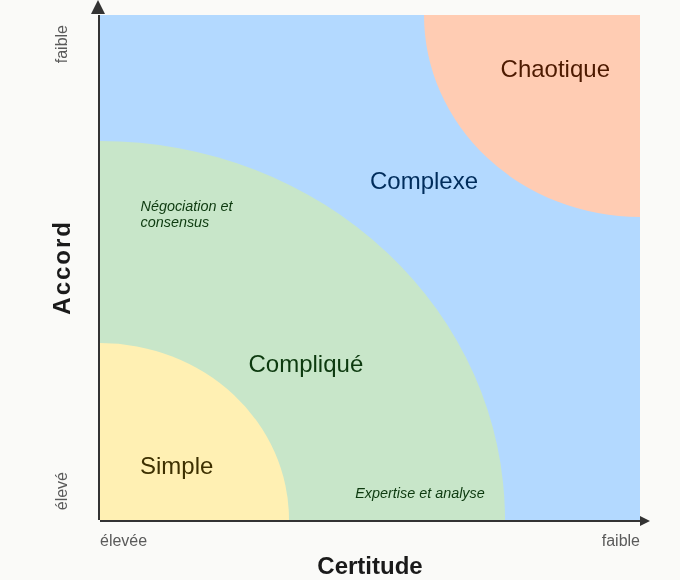

### Les pièges de la matrice

Ces deux axes semblent limpides en théorie. En pratique, quelques erreurs courantes peuvent fausser notre diagnostic.

#### Piège 1 : Confondre « compliqué » et « incertain »

Une tâche peut être techniquement compliquée tout en ayant une certitude élevée sur les moyens. Une migration d’ERP (*Enterprise Resource Planning*, progiciel de gestion intégré) est compliquée, certes, mais nous avons des méthodologies éprouvées, des consultants experts, des cas similaires documentés. L’incertitude porte sur l’exécution dans notre contexte spécifique, pas sur l’existence d’une solution viable. Si tout le monde est d’accord sur la nécessité de migrer, nous sommes dans le compliqué, pas dans le complexe.

#### Piège 2 : Croire qu’un objectif clair signifie un accord élevé

Un objectif peut sembler clair en apparence mais cacher un désaccord profond. « Améliorer la satisfaction client » peut sembler évident, mais le service client veut plus de support humain, la tech veut plus d’automatisation, et le marketing veut plus de fonctionnalités. L’objectif semble clair, mais l’accord est faible sur ce que « améliorer » signifie vraiment.

#### Piège 3 : Croire que « accord élevé » signifie « objectif simple »

L’accord peut être total sur un objectif extrêmement ambitieux. « Poser un humain sur Mars » : tout le monde à la NASA est d’accord sur cet objectif d’une clarté cristalline. Mais la certitude sur les moyens reste extraordinairement faible. L’accord ne dit rien de la difficulté ou de l’incertitude technique.

#### Piège 4 : Penser que maîtriser une technologie garantit la certitude

Connaître React ne rend pas automatiquement certain le chemin pour construire une application React spécifique. Si cette application est innovante, résout un problème nouveau, ou nécessite des performances jamais atteintes, la certitude reste faible, même si la technologie de base est familière. La certitude porte sur la relation complète entre actions et résultats, pas seulement sur les outils.

### L’indépendance des axes : La puissance du modèle

Armés de cette compréhension et conscients de ces pièges, nous pouvons maintenant explorer la vraie puissance du modèle de Stacey : **ces deux axes sont indépendants**. On peut avoir n’importe quelle combinaison d’accord et de certitude, et chaque combinaison crée un contexte de décision radicalement différent.

#### Cas 1 : Accord élevé + Certitude élevée = Zone SIMPLE

*« Renouveler les certificats SSL (*Secure Sockets Layer*, protocole de chiffrement) de nos serveurs. »*

Tout le monde est d’accord sur ce qu’il faut faire : maintenir des certificats valides. Et nous savons exactement comment faire : nous avons une procédure établie et automatisée. C’est simple, au sens où il n’y a ni désaccord ni incertitude significative.

*« Migrer 500 applications vers le cloud. »*

Tout le monde est d’accord sur l’objectif : toutes nos applications doivent fonctionner dans le cloud plutôt que dans nos datacenters. L’accord est clair et stable. Mais comment ? Pour chaque application, il faut analyser son architecture, ses dépendances, choisir entre *lift & shift*, *replatforming* ou *refactoring*. Il y a des centaines de décisions techniques à prendre, nécessitant expertise et analyse approfondie. C’est compliqué, mais pas complexe, car nous savons que des solutions existent et nous sommes d’accord sur l’objectif.

*« Améliorer l’expérience développeur dans notre organisation. »*

Techniquement, nous maîtrisons les solutions : nous savons créer des outils en ligne de commande, rédiger de la documentation, construire des portails développeur, mettre en place des *pipelines* d’intégration et de déploiement continus. La certitude technique est élevée.

Mais qu’est-ce qui va réellement améliorer leur expérience ? Différents groupes ont des priorités différentes. Certains veulent de l’autonomie, d’autres de la stabilité, d’autres encore de la rapidité. Il faut découvrir ce qui compte vraiment pour créer un consensus, et cette compréhension va évoluer au fur et à mesure. L’accord est faible ou émergent.

*« Créer une nouvelle offre SaaS (*Software as a Service*, logiciel en tant que service) disruptive pour notre marché. »*

Les parties prenantes ont des visions différentes de ce que devrait être le produit, qui devrait être la cible, quel problème résoudre en priorité. (Accord faible)

De plus, personne ne sait exactement quelle architecture, quelle stack technologique, ou comment gérer la scalabilité dès le départ. Faut-il développer ou composer avec des services existants ? (Certitude faible)

Nous sommes en pleine complexité, où chaque pas révèle de nouvelles informations qui modifient à la fois notre compréhension du problème et de la solution.

#### Cas 5 : La zone CHAOTIQUE

*« Notre base de données principale vient de tomber en production, nous perdons 100k€ par minute. »*

Au-delà de la complexité existe un territoire où l’accord et la certitude sont si faibles, ou la situation si instable, qu’il n’est plus possible de réfléchir : il faut agir immédiatement pour stabiliser.

Personne n’a le temps de débattre de l’objectif ou d’analyser les causes profondes. Il faut arrêter l’hémorragie maintenant, puis on comprendra après. C’est le mode crise, où l’action précède la compréhension.

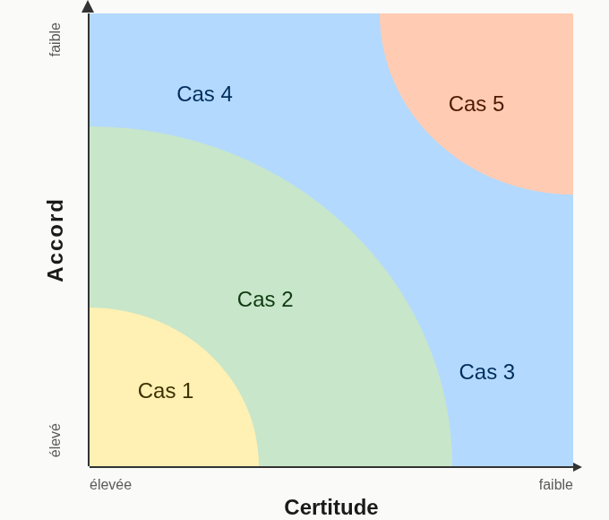

**En résumé visuel** : La matrice de Stacey nous révèle que deux projets peuvent sembler similaires en taille ou budget, mais radicalement différents par leur nature. Un projet « simple » demande de l’exécution, un projet « compliqué » demande de l’expertise, un projet « complexe » demande de l’exploration, et une crise « chaotique » demande de l’action immédiate. **La première question stratégique n’est donc pas « comment », mais « quel type de problème » ?**

### Deux questions avant tout

Avant d’aborder n’importe quel défi, la matrice de Stacey se résume à deux questions. Pour l’accord : les parties prenantes s’entendent-elles sur l’objectif final, et ce consensus est-il stable ? Pour la certitude : comprenons-nous les relations de cause à effet, avons-nous déjà résolu un problème similaire ? Les réponses ne déterminent pas la difficulté du travail, mais **la nature de l’approche** à adopter. Si la certitude manque, nous sommes en territoire compliqué ou complexe. Si l’accord manque, c’est le désaccord qu’il faut traiter en priorité.

Mais un diagnostic, aussi précis soit-il, ne nous dit pas encore *pourquoi* certains terrains se prêtent à l’accord et à la certitude, et d’autres non. La matrice de Stacey est une excellente boussole pour cartographier notre perception collective de l’incertitude. Elle répond à la question : « Où nous situons-nous *par rapport* au problème ? »

Mais pour affiner notre conscience situationnelle, nous devons aller plus loin et interroger la nature même du terrain. L’incertitude que nous ressentons est-elle due à un manque d’information de notre part, ou est-elle une propriété intrinsèque du système dans lequel nous opérons ?

Car certains systèmes sont, par nature, prévisibles. Imaginons-les comme des systèmes **macroscopiques**, composés d’éléments **stables** et bien définis, à l’image de molécules dans un cristal. La stabilité de chaque « brique » garantit la prévisibilité de l’édifice. Le comportement de l’ensemble est la somme prévisible du comportement de ses parties. D’un point de vue thermodynamique[^2], ce sont des systèmes où l’**entropie** (le degré de désordre ou d’imprévisibilité) est faible ou augmente très lentement. Leur état futur est une extrapolation logique de leur état présent.

D’autres systèmes, en revanche, fonctionnent à une échelle différente. Leur stabilité globale, paradoxalement, naît du tourbillon incessant d’un très grand nombre de composants **individuellement imprévisibles**. Pensez à un tourbillon dans une rivière : la forme du tourbillon est stable et reconnaissable, mais il est impossible de prédire la trajectoire d’une seule molécule d’eau à l’intérieur. Ici, le comportement de l’ensemble **n’est pas** la somme de ses parties ; il est une **propriété émergente** de leurs interactions. Dans ces systèmes, l’**entropie** est élevée et toute interaction peut créer un nouvel état, rendant le futur fondamentalement non déterministe.

Confondre un **mécanisme prévisible** (dont le désordre est faible) avec un **écosystème émergent** (dont l’ordre naît d’interactions imprévisibles) est l’erreur qui nous pousse à appliquer les mauvaises méthodes. C’est pourquoi, pour compléter notre boussole, nous avons besoin d’un cadre qui ne qualifie plus notre perception, mais bien la physique du système lui-même.

Ce cadre, c’est le modèle Cynefin. Rassurez-vous, ce n’est pas une simple matrice de plus, mais un « dispositif de création de sens » qui nous apprend à reconnaître l’« habitat » dans lequel nous nous trouvons. En distinguant la nature des relations de cause à effet, il nous donne la clé finale pour lire le terrain de jeu avant même de penser à agir.

## Cynefin : Lire la physique des systèmes

Ainsi, Cynefin[^3] est plus qu’un simple modèle, c’est un outil pour diagnostiquer la **nature de la causalité**. Son nom, issu du gallois, évoque la notion d’*habitat*, de « lieu d’appartenance ».

**Mise en garde :** Le cadre Cynefin est bien plus vaste que ce que nous allons présenter ici. C’est un ensemble riche de méthodes et d’approches qui guident non seulement le diagnostic, mais aussi l’action. Il propose des stratégies concrètes pour intervenir dans chaque type de système.

Cependant, l’objectif de ce chapitre n’est pas de vous transformer en expert du cadre Cynefin dans sa totalité. Il est prématuré, à ce stade de notre voyage, de parler de « comment agir ». Notre unique but ici est d’emprunter une partie de son puissant modèle de diagnostic pour affiner notre conscience situationnelle. Nous utilisons Cynefin comme une lentille pour mieux **lire le paysage** et comprendre la nature du brouillard dans lequel nous nous trouvons. L’art de naviguer activement dans ces territoires fera l’objet de chapitres ultérieurs.

Pour l’instant, concentrons-nous sur sa première et plus fondamentale leçon : tous les environnements ne sont pas régis par les mêmes lois physiques.

### La grande distinction : Deux physiques pour un même monde

La première leçon de Cynefin est qu’il n’existe pas une, mais deux physiques fondamentales qui gouvernent les systèmes que nous cherchons à maîtriser.

#### Les systèmes ordonnés

Parlons tout d’abord des systèmes ordonnés. Le mot « ordre » lui-même est fascinant. Il vient du latin ordo, qui désignait une rangée ou une succession régulière. Mais il a aussi donné le mot « ordonner », au sens de « donner un commandement ».

Cette double signification capture l’essence de l’informatique d’entreprise qui a dominé jusqu’au début des années 2000. Son rôle était précisément d’exécuter des ordres de manière fiable et répétable. On attendait d’elle qu’elle soit un système robuste et discipliné, qui traite des processus préétablis (une paie, une commande, une transaction comptable) sans jamais dévier de la ligne.

Le principe d’architecture des solutions informatiques qui a incarné cette philosophie est le monolithe. Comme un régiment en rangs serrés, le monolithe est une structure unique, massive et intégrée. Chaque composant a une place et une fonction définies dans une hiérarchie claire. On peut le planifier, l’optimiser et le contrôler de manière centralisée. Sa causalité est linéaire : une commande en entrée produit un résultat prévisible en sortie.

Un système ordonné est donc, fondamentalement, un système conçu pour recevoir et exécuter un ordre avec une prévisibilité maximale. Sa qualité première est la robustesse, car toute sa structure est pensée pour garantir la stabilité et l’efficacité dans l’exécution de tâches connues. Il n’est pas conçu pour l’imprévu, il est conçu pour l’obéissance.

Dans le cadre Cynefin, les systèmes ordonnés se décomposent en deux **domaines** (des catégories définies par la nature des relations de cause à effet qui y règnent). Le premier est celui de l’évident (ou clair), des choses simples que, pour des raisons évidentes, nous n’approfondirons pas davantage (si ce n’est pas clair pour le lecteur, c’est que le jeu de mots a raté : passons au domaine suivant). Le second est le domaine du compliqué : il contient l’ensemble des problèmes qui possèdent au moins une solution, même cachée. C’est le domaine des « connus inconnus » : nous savons qu’il y a une réponse, nous avons juste besoin de la trouver.

Plusieurs caractéristiques distinguent le domaine du compliqué (dont un certain nombre est attribuable indirectement à Keith Grint[^4]).

**On peut le décomposer pour le comprendre.** C’est la clé. Pour comprendre un moteur de voiture, un mécanicien le démonte. Pour analyser un monolithe, un architecte logiciel en cartographie les modules : le service d’authentification, le moteur de facturation, la gestion des stocks… Chaque pièce a une fonction définie. Le comportement de l’ensemble, bien que difficile à saisir d’un seul coup, est la somme du comportement de ses parties. L’approche « diviser pour régner » fonctionne ici.

**Il est gouverné par des règles stables et des experts.** Le succès appelle le succès car les règles du jeu sont fixes. Réparer une panne sur un modèle de voiture une fois vous rend plus apte à la réparer une seconde fois. C’est pourquoi ce domaine est le royaume des experts : l’expert n’invente rien, il applique un savoir profond pour analyser le système, identifier la cause du problème parmi une multitude de possibilités, et appliquer la bonne solution. Les méthodes standards fonctionnent bien parce que les problèmes se ressemblent.

**La causalité est une chaîne à découvrir.** C’est le monde des plans et des procédures. Pour construire un pont, on suit un plan d’ingénierie étape par étape. La relation de cause à effet, même masquée par des milliers de pièces interconnectées, est stable et découvrable. Si vous tournez cette vis, cela actionnera toujours ce levier. Si l’analyse de l’expert est correcte et que la procédure est bien exécutée, le résultat est garanti.

**Appliqué à notre projet CRM (*Customer Relationship Management*, gestion de la relation client) :** La **migration des données** de l’ancien système vers le nouveau est un défi purement **compliqué**. C’est un cauchemar technique qui nécessite des experts en bases de données et des analystes. Il faut créer un plan de migration détaillé (un script séquentiel), mapper chaque ancien champ vers un nouveau, nettoyer les données, et exécuter des tests. Le processus est ardu, mais il n’y a pas de surprise : si le mapping est correct et les scripts bien écrits, les données seront migrées avec succès. C’est un puzzle difficile, mais un puzzle avec une solution.

En résumé, un système compliqué est un défi pour notre intelligence analytique, pas un mystère pour notre intuition. Il peut être démonté, analysé et maîtrisé par ceux qui possèdent le savoir adéquat.

#### Les systèmes désordonnés

En opposition aux systèmes ordonnés, nous trouvons logiquement les systèmes désordonnés. Dans le cadre de travail Cynefin, ces systèmes sont décomposés en deux domaines :

**Le domaine chaotique** représente le territoire de la crise pure. Ici, il n’existe aucun lien de corrélation évident entre cause et effet. Le système est si instable qu’il est impossible de prédire quoi que ce soit. L’action doit précéder l’analyse : on agit d’abord pour stabiliser, on comprend ensuite. Une panne majeure en production, un incident de sécurité critique, ou une catastrophe naturelle relèvent de ce domaine. La seule stratégie viable est de ramener rapidement le problème dans un domaine plus stable (complexe ou compliqué) en prenant des actions immédiates pour contenir la situation. Nous n’approfondirons pas davantage ce domaine car il sort du cadre stratégique de ce livre : dans le chaos, il n’y a pas de stratégie, seulement de la survie.

**Le domaine du complexe**, en revanche, mérite toute notre attention. C’est le domaine des « inconnus inconnus » : nous ne savons même pas quelles questions poser pour commencer à adresser le problème.

**On ne peut pas le décomposer sans le détruire.** C’est la règle d’or. Si vous décomposez un écosystème en ses parties (les arbres, la terre, les animaux), vous n’avez plus la forêt. Vous avez perdu l’essentiel : les **interactions**. Dans un système complexe, le tout est *différent* de la somme de ses parties. Tenter de le simplifier, c’est comme essayer de comprendre une blague en analysant la définition de chaque mot dans le dictionnaire. Vous perdez le sens.

**Le passé ne prédit pas le futur.** Ici, le succès est un mauvais professeur. Chaque action que vous entreprenez **modifie le système lui-même**. Une campagne marketing qui a fonctionné une fois a éduqué le marché et les concurrents, rendant sa reproduction impossible. L’expertise, bien qu’utile, peut même devenir un piège, car l’expert cherche à appliquer des solutions passées à un contexte qui est, par définition, unique. Chaque situation est une première fois.

**La causalité est une toile d’araignée que l’on ne voit qu’après coup.** Oubliez la chaîne de cause à effet. Ici, les problèmes sont interconnectés et une petite action dans un coin du système peut avoir des conséquences énormes et imprévisibles ailleurs. On ne comprend la causalité qu’**en rétrospective** : une fois que l’événement s’est produit, il nous semble évident, mais avant, il était impossible à prédire. C’est le biais de rétrospection, le plus grand piège du domaine complexe.

**L’incertitude est une constante, pas un défaut.** Dans un système compliqué, l’incertitude est un manque d’information que l’on peut combler par l’analyse. Dans un système complexe, l’incertitude est une caractéristique fondamentale du terrain. On ne peut pas l’éliminer, on doit apprendre à naviguer avec.

**Appliqué à notre projet CRM :** L’**adoption du CRM par les équipes** est un défi purement **complexe**. Vous pouvez avoir le meilleur outil (compliqué), mais faire en sorte que les commerciaux, habitués à leurs propres méthodes, l’utilisent réellement est un autre jeu. Ce défi implique la culture d’entreprise, les jeux de pouvoir, les habitudes individuelles, la peur du changement… C’est un écosystème social. Une formation qui fonctionne avec l’équipe A peut échouer avec l’équipe B. Forcer l’usage peut créer une résistance passive (les gens remplissent le minimum). Vous ne pouvez pas planifier l’adoption ; vous devez l’encourager, l’observer, et la cultiver, comme un jardinier.

En résumé, un système complexe ne se résout pas, il se navigue. Il ne se contrôle pas, il s’influence. Il ne demande pas des experts qui ont les réponses, mais des leaders qui posent les bonnes questions et permettent à des solutions d’émerger par l’expérimentation.

Résumons les deux physiques en vis-à-vis :

| Caractéristique | Domaine Compliqué | Domaine Complexe |
| --- | --- | --- |
| **Nature du Problème** | **« Connus inconnus »** Il existe au moins une solution, même si elle est cachée. C’est un puzzle difficile. | **« Inconnus inconnus »** On ne sait même pas quelles questions poser. C’est un mystère. |
| **Analyse / Décomposition** | **On peut le décomposer pour le comprendre.** Le tout est la somme de ses parties. L’approche « diviser pour régner » fonctionne. | **On ne peut pas le décomposer sans le détruire.** Le tout est différent de la somme de ses parties à cause des interactions. |
| **Causalité** *(Relation de Cause à Effet)* | **Une chaîne à découvrir.** La causalité est linéaire, stable et découvrable par l’analyse. | **Une toile d’araignée vue après coup.** Les relations sont interconnectées et la causalité n’est comprise qu’en rétrospective. |
| **Prédictibilité / Rôle du Passé** | **Le passé prédit le futur.** Les règles sont stables. Un succès peut être reproduit. | **Le passé ne prédit pas le futur.** Le système change avec chaque action, rendant la reproduction d’un succès incertain. |
| **Rôle de l’Expertise** | **Le royaume des experts.** L’expert applique un savoir profond pour trouver la bonne solution parmi plusieurs possibilités. | **L’expertise n’est pas une garantie.** Elle peut même être un piège si l’expert applique des solutions passées à un contexte unique. |
| **Approche / Stratégie** | **Analyser, planifier, exécuter.** On suit des plans et des procédures standards pour atteindre un résultat garanti. | **Sonder, sentir, répondre.** On navigue, on influence et on apprend par l’expérimentation pour laisser des solutions émerger. |
| **Gestion de l’Incertitude** | **L’incertitude est un manque d’information.** On peut la réduire par l’analyse. Le résultat est prévisible. | **L’incertitude est une caractéristique fondamentale.** On ne peut pas l’éliminer, on doit apprendre à naviguer avec. |

Ces différences conceptuelles se traduisent concrètement dans la façon dont nous abordons le travail. **Si le tableau précédent vous aide à diagnostiquer la nature du système, le tableau suivant vous donne les règles du jeu pour y opérer efficacement.** C’est la différence entre comprendre qu’on est dans la jungle (diagnostic) et savoir comment s’y déplacer (action) :

| Question | Domaine Compliqué | Domaine Complexe |
| --- | --- | --- |
| **Peut-on faire un plan détaillé avant de commencer ?** | Oui, et on devrait | Non, et c’est normal |
| **Le rôle des experts** | Concevoir la solution | Accompagner la découverte |
| **Comment mesurer le succès** | Conformité au plan | Vitesse d’apprentissage |
| **Nature du budget** | Financer un plan | Acheter des options d’apprentissage |
| **Attitude face aux écarts** | Anomalie à corriger | Signal à exploiter |

Enfin, dans une idée de complétude de la description du cadre Cynefin, mentionnons qu’il existe un dernier domaine : celui du **désordre** (parfois appelé « confusion »). Ce n’est pas une catégorie à part entière, mais plutôt l’état dans lequel nous nous trouvons quand nous ne savons pas encore dans quel domaine situer notre problème. Le brouillard est si épais que nous ne savons même pas si nous sommes dans le simple, le compliqué, le complexe ou le chaotique. Dans ce cas, la première action est précisément de lever ce brouillard en posant les bonnes questions (celles que nous venons de découvrir avec Stacey).

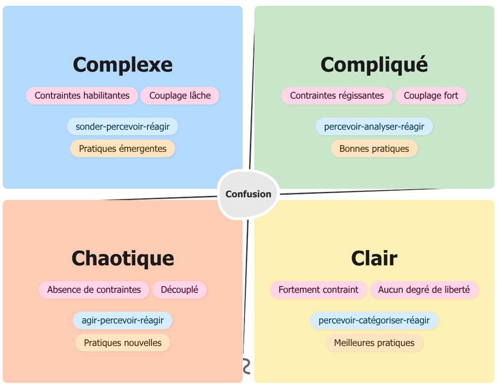

*Représentation du cadre Cynefin par Tom@thomasbcox.com sous licence CC-BY-SA-4.0*

Nous disposons maintenant d’une double boussole pour naviguer dans le brouillard. La matrice de Stacey vous a permis de prendre la température de votre groupe face à l’inconnu, tandis que Cynefin vous a révélé la nature même du terrain (la physique des causes et des effets).

### Stacey et Cynefin : Deux boussoles, un même nord

Ces deux cadres ne sont ni redondants ni interchangeables. Ils répondent à des questions différentes et se complètent :

|  | **Matrice de Stacey** | **Cadre Cynefin** |
| --- | --- | --- |
| **Question posée** | Quel est **notre** niveau d’incertitude face au problème ? | Quelle est la **nature** du système dans lequel nous opérons ? |
| **Ce qu’on évalue** | La perception du groupe (accord + certitude) | La physique du terrain (relations de cause à effet) |
| **Axes / Dimensions** | Accord × Certitude (deux axes indépendants) | Ordonnés vs Désordonnés (nature de la causalité) |
| **Usage principal** | Diagnostic d’équipe : « Sommes-nous alignés ? » | Diagnostic de terrain : « Quel type de problème est-ce ? » |
| **Point fort** | Révèle les désaccords cachés entre parties prenantes | Empêche d’appliquer les mauvaises méthodes |

**En pratique, par où commencer ?**

1. **Commencez par Stacey** pour évaluer où se situe votre groupe : y a-t-il un accord sur l’objectif ? une certitude sur les moyens ? Ce diagnostic est rapide et immédiatement actionnable.
2. **Puis affinez avec Cynefin** pour comprendre si l’incertitude que vous ressentez est réductible (compliqué : il suffit d’analyser davantage) ou irréductible (complexe : il faut expérimenter).
3. **Si Stacey dit « complexe » mais Cynefin dit « compliqué »**, c’est probablement un problème de communication : le groupe manque d’information, pas le terrain. Investissez dans l’expertise.
4. **Si Stacey dit « simple » mais Cynefin dit « complexe »**, attention : le groupe est en faux consensus. L’accord apparent masque une réalité plus turbulente. C’est la situation la plus dangereuse.

## Utiliser la boussole (mode d’emploi pratique)

Une mise en garde est nécessaire avant d’aller plus loin. La stratégie, même la plus technique, reste une discipline profondément humaine. Croire qu’un modèle, aussi puissant soit-il, peut résoudre à lui seul un désaccord ou forcer un alignement relève de l’illusion méthodologique. Avant l’outil, il y a la discussion. Avant le diagnostic, il y a la confiance.

Le modèle est un instrument d’alignement, mais il faut au préalable s’aligner sur l’utilisation de l’instrument. Votre première victoire n’est pas d’avoir raison avec un modèle, mais de créer un accord pour l’utiliser. Ce livre ne prétend pas vous enseigner l’art complexe de la persuasion, qui est propre à chaque personnalité et à chaque culture d’entreprise. Nous nous contenterons de résumer cette compétence sous le terme de **rhétorique**, ou l’art de convaincre.

C’est pourquoi nous vous proposons une approche en deux temps :

1. **D’abord, utilisez ces modèles intérieurement.** Faites-en vos outils de pensée personnels pour décoder les situations. Laissez-les infuser votre jugement et se confronter à vos expériences jusqu’à vous forger une conviction intime de leur utilité.
2. **Ensuite, une fois la conviction forgée,** utilisez la rhétorique pour partager non pas le modèle lui-même, mais les **clartés** qu’il vous a apportées. Votre but n’est pas de dire « selon Stacey… », mais d’aider le groupe à voir ce que vous voyez.

Les exemples qui suivent sont conçus pour vous aider dans ce parcours. Ils vous montreront comment utiliser la boussole pour vous forger une conviction, et comment la rhétorique permet de transformer cette conviction en un mouvement collectif.

### Diagnostiquer les maux du quotidien

#### Cas succinct : « La réunion tourne en rond depuis une heure. »

- **Symptôme :** Les mêmes arguments tournent en boucle. Les débats sont stériles. Personne ne converge.
- **Diagnostic Rapide (Votre Conviction) :** C’est le signe d’un désaccord fondamental sur la nature du problème.
- **Antidote (Rhétorique) :** « Puis-je tenter une reformulation ? J’ai l’impression que la moitié d’entre nous traite ce problème comme un puzzle dont il faut trouver la solution (Compliqué), tandis que l’autre moitié le voit comme un mystère à démêler pas à pas (Complexe). Tant qu’on ne sera pas d’accord sur la *nature* du problème, on ne pourra pas s’accorder sur la méthode pour le résoudre. »

#### Cas succinct : « Chacun défend SON plan et personne n’écoute. »

- **Symptôme :** C’est une bataille d’egos. Chaque intervenant présente sa solution comme la seule viable. Le « théâtre de la stratégie » est à son paroxysme.
- **Diagnostic Rapide (Votre Conviction) :** Chacun traite le problème comme *Compliqué* (avec sa solution « experte »), alors que la situation est probablement *Complexe*.
- **Antidote (Rhétorique) :** « Je vois beaucoup de solutions excellentes sur la table. Mais avant de comparer nos plans, pourrions-nous répondre à une question : sommes-nous en train de choisir la meilleure recette de cuisine parmi des recettes connues (Compliqué), ou d’inventer un plat entièrement nouveau (Complexe) ? Car si nous inventons, aucune de nos solutions n’est la bonne pour l’instant ; ce sont juste des hypothèses à tester. »

#### Cas détaillé : « On nous demande un planning détaillé, mais on ne sait même pas ce qu’on construit. »

**Le Symptôme : Le mot à la mode « IA-Powered »**

Imaginez la scène. La Direction prend la parole :

**Direction :** « Nous devons devenir IA-Powered d’ici le second trimestre. »

**CTO (*Chief Technology Officer*, le directeur technique) :** « De quelles capacités IA parlons-nous exactement ? »

**PM (*Project Manager*, le chef de projet) :** « Ma feuille de route actuelle ne prévoit pas cela… »

**Direction :** « Adaptez le planning. »

**CTO :** « Introduire l’IA n’est pas un simple ajout, c’est un changement de paradigme complet. »

**Marketing :** « Mes clients attendent une évolution, pas une révolution. »

*Silence. Personne ne parle le même langage.*

**Votre diagnostic avec la boussole :** - **Accord (Stacey)** : Désastre. Chacun veut quelque chose de différent. - **Certitude (Stacey)** : Pire encore. Personne ne sait comment faire. - **Nature du problème (Cynefin)** : Domaine Complexe.

**Votre intervention (rhétorique, pas théorie) :**

« Stop. Nous ne sommes d’accord ni sur l’objectif, ni sur les moyens. C’est le signe que nous ne pouvons pas planifier. Nous devons explorer. Je propose qu’on définisse la première expérience, la moins chère possible, pour apprendre quelque chose d’ici la semaine prochaine. »

**Le Mur de l’Organisation**

Votre proposition semble débloquer la situation. Un silence s’installe, puis le PM hoche la tête, suivi par le CTO. Mais alors que vous pensez avoir gagné, le PM ajoute :

**PM :** « L’idée d’une expérience est bonne, mais comment je la finance ? Mon budget est alloué par fonctionnalité planifiée. Je n’ai pas de ligne pour une « expérience d’apprentissage ». Le PMO (*Project Management Office*, le bureau chargé de superviser et de cadrer l’ensemble des projets de l’organisation) va me demander un *business case* (un dossier d’opportunité) avec un *ROI* (*Return On Investment*, retour sur investissement) sur 3 ans avant de débloquer le moindre euro. »

Et voilà le mur. Votre boussole a fonctionné : vous avez identifié le bon domaine (Complexe) et proposé la bonne approche (Sonder). Mais le véhicule (l’organisation, avec ses processus budgétaires rigides) est conçu pour rouler uniquement sur des autoroutes (le Compliqué). Vous savez où aller, mais l’organisation est incapable de bouger. C’est ce que nous étudierons dans le prochain chapitre.

**ANTISÈCHE : Répondre aux Objections en Comex**

**« Pourquoi pas de plan détaillé ? »** → « Ce territoire évolue trop vite. Un plan détaillé maintenant serait cartographier une jungle avant d’avoir trouvé les sentiers. Ce que je peux donner : un plan d’apprentissage, une série d’expérimentations. »

**« C’est trop risqué, nous avons besoin de certitudes. »** → « Le vrai risque est l’inaction. Nos concurrents sont déjà dans ce territoire. Réduire le risque passe par des expérimentations rapides et peu coûteuses, pas par plus d’études. »

**« Pourquoi changer notre méthodologie ? »** → « Notre méthodologie X excelle sur les territoires maîtrisés. Ce projet est un territoire où les règles se découvrent en marchant. C’est la différence entre un GPS sur autoroute et une boussole en forêt vierge. »

## Conclusion : Qualification à la vision stratégique

Le changement de paradigme que nous venons d’opérer est fondamental. Votre première décision stratégique n’est plus « Quelle solution choisir ? » mais **« Dans quel territoire sommes-nous ? »**. Cette simple question transforme un débat d’opinion en un diagnostic partagé. Elle peut faire taire le « théâtre de la stratégie » et libère enfin l’intelligence collective.

Vous êtes désormais équipé d’une boussole. Elle vous empêchera d’appliquer les mauvaises méthodes aux mauvais problèmes. Elle vous évitera de demander un plan détaillé pour explorer une jungle, ou de lancer un comité d’analyse pour combattre un incendie. C’est un pas décisif pour naviguer dans le brouillard de l’incertitude.

Mais si la boussole vous empêche de vous perdre, elle ne vous dit pas encore où aller pour gagner.

Une boussole, aussi puissante soit-elle, a ses limites. Elle vous aide à qualifier un point sur le terrain, mais elle ne vous montre pas le paysage. Elle vous donne un diagnostic à l’instant T, mais elle ne vous dit rien sur le mouvement inévitable qui anime ce paysage. Surtout, elle est tournée vers l’intérieur, vous aidant à mieux gérer *vos* projets, sans vous montrer ce que font *vos concurrents* sur le même terrain de jeu.

Pour maîtriser l’art du mouvement, nous devrons passer de la boussole, qui qualifie un point, à la **carte**, qui révèle le paysage, son évolution et les coups possibles.

Mais une carte n’a de valeur que si l’on est capable de se déplacer sur le terrain qu’elle représente.

Avant de chercher à cartographier le monde extérieur, une question encore plus fondamentale se pose : **votre organisation est-elle seulement prête à bouger ?** Savoir que vous devez explorer la jungle ne sert à rien si tous vos processus, vos budgets et vos modes de pensée sont exclusivement conçus pour construire des ponts. Vous aurez beau pointer la bonne direction avec votre boussole, l’organisation refusera de faire le premier pas dans les fourrés.

Connaître la bonne stratégie est une chose. Avoir une organisation capable de l’exécuter en est une autre. C’est pourquoi, avant d’apprendre à dessiner la carte, nous devons d’abord faire le diagnostic de notre propre véhicule.

C’est l’objet de notre prochain chapitre : sonder la « doctrine » de votre organisation, sa culture et sa capacité intrinsèque au mouvement.

[^1]: Ralph D. Stacey, *Strategic Management and Organisational Dynamics: The Challenge of Complexity*, 6e édition, Pearson, 2011 (1re édition 1996).
[^2]: **Précision importante :** Cette analogie est pédagogique, pas scientifique. Les organisations ne sont pas des systèmes thermodynamiques fermés. L’entropie organisationnelle est une métaphore pour illustrer la différence de prévisibilité entre systèmes ordonnés et complexes. Ne citez pas ce passage dans une thèse de physique.
[^3]: Cadre conceptuel développé par Dave Snowden alors qu’il travaillait chez IBM Global Services, puis au sein de Cognitive Edge (aujourd’hui The Cynefin Co). Voir David J. Snowden et Mary E. Boone, « A Leader’s Framework for Decision Making », *Harvard Business Review*, novembre 2007.
[^4]: Keith Grint, « Wicked Problems and Clumsy Solutions: The Role of Leadership », *Clinical Leader*, vol. 1, n° 2, 2008.

v2.16.0-beta